# Using features of dynamic networks to guide treatment selection and outcome prediction

- Show All Code
- Hide All Code
- View Source

Empirical Example

Authors

Affiliations

Björn S. Siepe

University of Marburg

Matthias Kloft

University of Marburg

Fridtjof Petersen

University of Groningen

Yong Zhang

University of Groningen

Laura F. Bringmann

University of Groningen

Daniel W. Heck

University of Marburg

Published

November 17, 2025

# 1 Preparation

In this document, we will use an empirical data set to demonstrate the results of different network analysis techniques.

```r
# Libraries
library(plyr)
library(tidyverse)
library(graphicalVAR)
library(mlVAR)
library(here)
library(gimme)
library(rstan)
library(imputeTS)
library(knitr)
library(gt)
library(bayesplot)
library(broom)
library(MetBrewer)
library(ggdist)
library(ggh4x)
library(sysfonts)
library(showtext)
# library(beeswarm)

source(here::here("scripts", "00_functions.R"))
set.seed(35037)
```

# 2 Data

Load data:

```r
data_bringmann <- readRDS(here::here("data", "data_Bringmann2016.RDS"))
```

## 2.1 Cleaning

Apparently, the neuroticism values are not imported correctly - the 95 values for different IDs are simply shown in the first 95 rows. We need to clean the data first.

```r
data_bringmann <- data_bringmann |>
  janitor::clean_names()

# obtain unique ids
all_ids <- unique(data_bringmann$subj_id)

# split of the neuroticism column, then reattach it to the correct id
neuroticism_vec <- data_bringmann |>
  select(subj_id, neuroticism) |>
  slice(1:95) |>
  # attach the correct id
  mutate(subj_id = all_ids)

data_bringmann <- data_bringmann |>
  select(!neuroticism) |>
  left_join(neuroticism_vec, by = "subj_id")
```

## 2.2 Descriptives & Missing Values

We first plot the distributions of all variables:

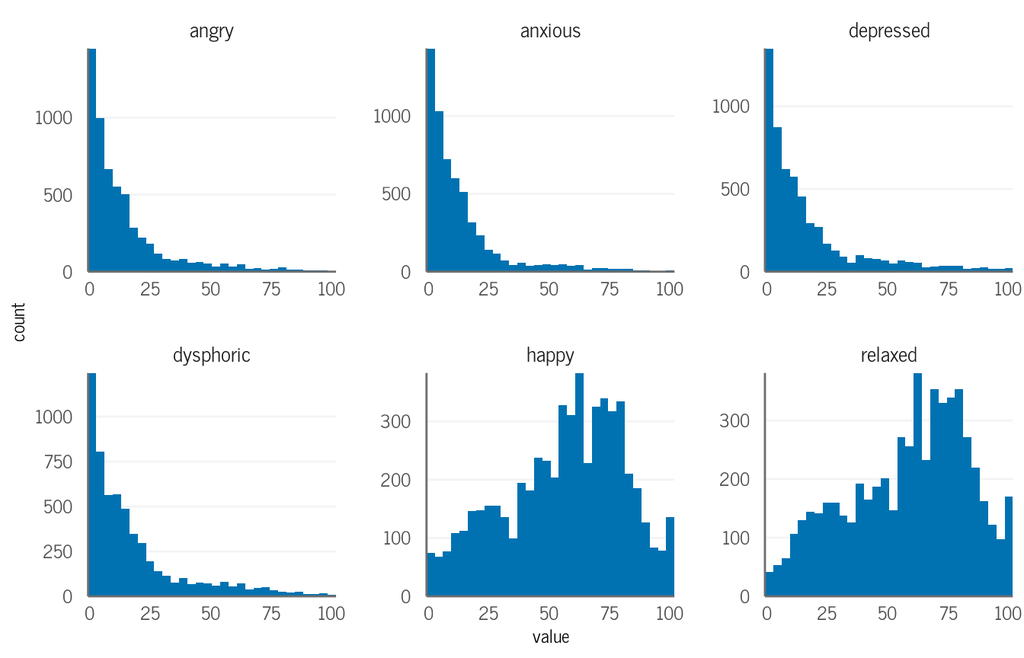

```r
data_bringmann |>
  select(-c(subj_id, neuroticism)) |>
  gather() |>
  ggplot(aes(value)) +
  geom_histogram(fill = "#0072B2") +
  facet_wrap(~key, scales = "free") +
  theme_centrality()+
  scale_x_continuous(expand = c(0, 0)) +
  scale_y_continuous(expand = c(0, 0))
```

We can see considerable skewness in the “negative” variables.

Next, we check for missing values by calculating the missingness proportions for each variable and subject:

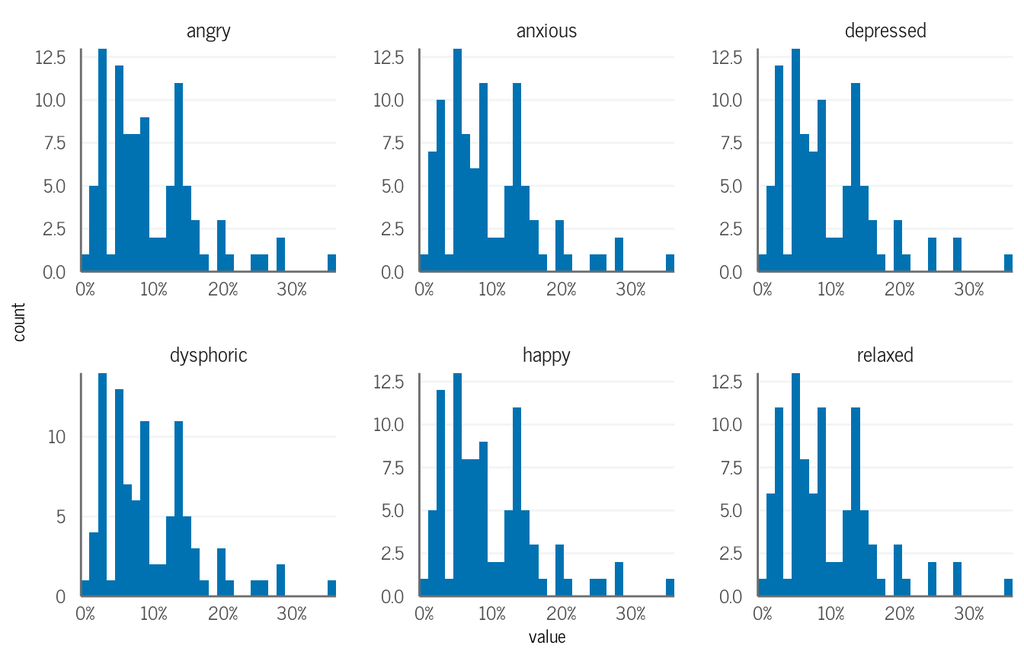

```r
data_bringmann |>
  select(-c(neuroticism)) |>
  group_by(subj_id) |>
  summarise_all(~sum(is.na(.x))/n()) |>
  select(-subj_id) |>
  gather() |>
  ggplot(aes(value)) +
  geom_histogram(fill = "#0072B2") +
  facet_wrap(~key, scales = "free") +
  theme_centrality()+
  scale_x_continuous(expand = c(0, 0), labels = scales::label_percent()) +
  scale_y_continuous(expand = c(0, 0))
```

Apparently, the missingness is almost identical for all variables.

Calculate the average missingness per person:

```r
data_bringmann |>
  dplyr::select(-c(neuroticism)) |>
  dplyr::group_by(subj_id) |>
  dplyr::summarise(across(everything(),
                   ~sum(is.na(.x))/n())) |>
  dplyr::summarise(across(everything(),
                   ~mean(.x, na.rm = TRUE))) |>
  # take average across all variables
  dplyr::select(!subj_id) |>
  dplyr::pull() |>
  mean()
```

```
[1] 0.09593745
```

We can now check for zero or very low variances per individual, and then filter them out:

```r
subj_to_exclude <- data_bringmann |>
  dplyr::select(-c(neuroticism)) |>
  dplyr::group_by(subj_id) |>
  dplyr::summarise(across(everything(),
                   ~var(.x, na.rm = TRUE))) |>
  dplyr::filter(if_any(everything(), ~.x < 1)) |>
  dplyr::pull(subj_id)

data_bringmann <- data_bringmann |>
  dplyr::filter(!subj_id %in% subj_to_exclude)

neuroticism_vec_clean <- data_bringmann |>
  dplyr::group_by(subj_id) |>
  dplyr::distinct(neuroticism) |>
  dplyr::pull(neuroticism)

subj_to_exclude |>
  knitr::kable()
```

| x |
| --- |
| 13 |
| 239 |
| 466 |

As we can see, they all have a very low variance for “depressed” and, in one case, for “dysphoric” and “anxious” as well.

We then create an overview table that gives the average of person-specific means, standard deviations, and non-missing observations for all variables:

```r
summary_table <- data_bringmann |>
  dplyr::select(-c(neuroticism)) |>
  dplyr::group_by(subj_id) |>
  dplyr::summarize(across(everything(),
                   list(mean = ~round(mean(.x, na.rm = TRUE), 2),
                          sd = ~round(sd(.x, na.rm = TRUE), 2),
                          obs = ~sum(!is.na(.x))),
                   .names = "{.col}_{.fn}"))

summary_table |>
  knitr::kable()
```

| subj_id | angry_mean | angry_sd | angry_obs | depressed_mean | depressed_sd | depressed_obs | dysphoric_mean | dysphoric_sd | dysphoric_obs | anxious_mean | anxious_sd | anxious_obs | relaxed_mean | relaxed_sd | relaxed_obs | happy_mean | happy_sd | happy_obs |
| --- | --- | --- | --- | --- | --- | --- | --- | --- | --- | --- | --- | --- | --- | --- | --- | --- | --- | --- |
| 2 | 2.45 | 6.06 | 58 | 3.24 | 8.41 | 58 | 5.43 | 10.50 | 58 | 3.59 | 6.36 | 58 | 58.83 | 18.43 | 58 | 58.02 | 20.17 | 58 |
| 3 | 14.14 | 9.35 | 58 | 8.03 | 6.34 | 58 | 15.72 | 8.67 | 58 | 7.57 | 7.91 | 58 | 60.29 | 14.88 | 58 | 59.79 | 10.47 | 58 |
| 4 | 20.82 | 21.46 | 55 | 14.04 | 17.18 | 55 | 21.11 | 20.00 | 55 | 15.47 | 17.66 | 55 | 43.87 | 19.01 | 55 | 47.09 | 17.79 | 55 |
| 6 | 14.15 | 21.02 | 62 | 12.10 | 19.26 | 62 | 13.05 | 22.40 | 62 | 7.26 | 8.22 | 62 | 56.21 | 21.50 | 62 | 47.16 | 20.86 | 62 |
| 8 | 3.84 | 6.50 | 64 | 3.42 | 5.97 | 64 | 8.56 | 13.58 | 64 | 3.42 | 6.86 | 64 | 68.83 | 20.69 | 64 | 70.83 | 18.42 | 64 |
| 9 | 6.97 | 11.80 | 62 | 6.02 | 11.08 | 62 | 11.02 | 17.69 | 62 | 6.73 | 15.21 | 62 | 73.52 | 20.39 | 62 | 73.37 | 19.60 | 62 |
| 10 | 6.27 | 8.96 | 49 | 4.52 | 11.32 | 50 | 2.92 | 6.15 | 49 | 2.20 | 2.10 | 49 | 79.50 | 15.16 | 50 | 80.00 | 19.16 | 49 |
| 12 | 17.75 | 13.93 | 61 | 21.87 | 18.56 | 61 | 16.61 | 13.51 | 61 | 16.54 | 16.07 | 61 | 58.38 | 14.67 | 61 | 56.77 | 16.68 | 61 |
| 20 | 21.19 | 16.37 | 57 | 15.14 | 12.54 | 57 | 19.77 | 14.02 | 57 | 20.11 | 8.15 | 57 | 50.09 | 21.49 | 57 | 57.60 | 20.59 | 57 |
| 23 | 25.16 | 21.07 | 64 | 32.34 | 22.37 | 64 | 34.50 | 23.01 | 64 | 40.85 | 20.98 | 65 | 54.36 | 20.20 | 64 | 44.17 | 19.66 | 64 |
| 26 | 8.80 | 12.29 | 59 | 44.58 | 19.86 | 59 | 52.63 | 22.60 | 59 | 9.71 | 9.60 | 59 | 75.08 | 21.42 | 59 | 43.73 | 22.41 | 59 |
| 28 | 6.45 | 4.50 | 62 | 12.18 | 7.12 | 62 | 16.92 | 10.02 | 62 | 7.08 | 4.21 | 62 | 63.87 | 12.08 | 62 | 62.47 | 12.73 | 62 |
| 31 | 16.87 | 9.82 | 62 | 17.68 | 8.34 | 62 | 30.84 | 17.66 | 62 | 13.61 | 9.30 | 62 | 57.15 | 21.87 | 62 | 44.97 | 17.18 | 62 |
| 34 | 26.65 | 13.86 | 63 | 31.11 | 18.24 | 63 | 28.60 | 15.05 | 63 | 27.25 | 13.42 | 63 | 54.75 | 22.45 | 63 | 58.02 | 20.71 | 63 |
| 38 | 14.10 | 14.15 | 61 | 11.93 | 7.61 | 61 | 15.05 | 10.24 | 61 | 12.89 | 7.44 | 61 | 49.70 | 25.22 | 61 | 50.21 | 25.98 | 61 |
| 39 | 9.74 | 12.49 | 58 | 3.26 | 2.36 | 58 | 5.78 | 9.14 | 58 | 6.31 | 10.02 | 58 | 72.16 | 15.67 | 58 | 72.50 | 13.76 | 58 |
| 41 | 20.59 | 17.15 | 61 | 21.31 | 18.11 | 61 | 39.57 | 22.75 | 61 | 18.48 | 13.86 | 61 | 57.87 | 22.72 | 61 | 52.80 | 24.20 | 61 |
| 43 | 19.51 | 16.14 | 65 | 32.60 | 20.47 | 65 | 27.38 | 18.21 | 65 | 24.45 | 19.25 | 65 | 53.83 | 22.28 | 65 | 56.00 | 20.17 | 65 |
| 46 | 14.05 | 15.62 | 61 | 10.79 | 5.59 | 61 | 13.62 | 13.07 | 61 | 10.25 | 3.58 | 61 | 62.92 | 26.08 | 61 | 64.85 | 19.18 | 61 |
| 47 | 17.93 | 21.02 | 54 | 14.91 | 13.02 | 54 | 15.70 | 15.38 | 54 | 14.31 | 12.57 | 54 | 66.26 | 26.77 | 54 | 48.78 | 24.68 | 54 |
| 48 | 3.58 | 8.12 | 62 | 1.40 | 1.25 | 62 | 3.90 | 11.66 | 62 | 5.05 | 7.91 | 62 | 55.92 | 18.61 | 62 | 48.81 | 9.08 | 62 |
| 52 | 18.10 | 12.13 | 58 | 14.45 | 9.18 | 58 | 14.97 | 8.17 | 58 | 13.22 | 7.98 | 58 | 63.74 | 12.30 | 58 | 67.33 | 8.15 | 58 |
| 57 | 16.97 | 11.84 | 64 | 19.56 | 12.62 | 64 | 18.31 | 11.45 | 64 | 17.06 | 13.83 | 64 | 34.33 | 18.99 | 64 | 36.75 | 17.80 | 64 |
| 74 | 9.85 | 10.50 | 48 | 9.35 | 8.93 | 48 | 9.62 | 9.99 | 48 | 7.65 | 3.61 | 48 | 61.94 | 22.76 | 48 | 53.06 | 16.16 | 48 |
| 82 | 6.95 | 3.59 | 43 | 6.56 | 2.84 | 43 | 7.21 | 3.85 | 43 | 7.74 | 5.36 | 43 | 66.72 | 21.87 | 43 | 77.88 | 11.16 | 43 |
| 84 | 3.35 | 4.56 | 62 | 1.95 | 1.68 | 62 | 3.89 | 5.51 | 62 | 2.85 | 4.10 | 62 | 61.21 | 13.28 | 62 | 61.35 | 14.81 | 62 |
| 90 | 7.75 | 12.47 | 59 | 7.20 | 9.40 | 59 | 9.32 | 14.99 | 59 | 7.54 | 11.29 | 59 | 73.37 | 18.90 | 59 | 57.76 | 18.35 | 59 |
| 105 | 13.09 | 10.34 | 64 | 14.50 | 7.96 | 64 | 20.72 | 11.74 | 64 | 8.80 | 6.37 | 64 | 49.91 | 17.10 | 64 | 46.39 | 18.32 | 64 |
| 107 | 9.98 | 22.92 | 52 | 86.58 | 18.82 | 52 | 61.29 | 30.83 | 52 | 62.04 | 26.98 | 52 | 22.65 | 23.37 | 52 | 26.35 | 20.37 | 52 |
| 124 | 31.36 | 19.65 | 58 | 32.09 | 20.08 | 58 | 35.24 | 19.97 | 58 | 29.97 | 16.99 | 58 | 49.60 | 23.96 | 58 | 50.09 | 24.31 | 58 |

[output cut: 62 more lines]

```r
n_non_miss <- summary_table |>
  dplyr::select(dplyr::ends_with("_obs")) |>
  unlist() |>
  mean()
```

The average number of non-missing observations is 60.17.

## 2.3 Imputation

Some of the methods require imputation, so we impute per person and per variable, using a Kalman filter approach.

```r
# Try higher number of iterations
new_param <- list(maxit = 5000)

data_bringmann_imputed <- data_bringmann |>
  dplyr::select(-neuroticism) |>
  dplyr::group_by(subj_id) |>
  dplyr::mutate(across(everything(),
                ~imputeTS::na_kalman(.x, optim.control = new_param),
                .names = "{.col}_imp")) |>
  dplyr::ungroup() |>
  dplyr::left_join(neuroticism_vec, by = "subj_id")

convergence_warnings<- dplyr::last_dplyr_warnings(n = 15)
```

We observe some potential convergence issues here (see [here](https://github.com/SteffenMoritz/imputeTS/issues/60) for more information). In this case, it makes sense to inspect the imputed values for the affected time series.

```r
# Obtain IDs with convergence issues
convergence_ids <- sapply(convergence_warnings, function(x){
  x$message[[2]] |>
    str_extract("(?<=subj_id = )\\d+") |>
    as.numeric()
})

# Check their time series
columns <- c("angry", "depressed", "dysphoric", "anxious", "relaxed", "happy")

pdf(here::here("figures", "empirical_example_imputations.pdf"))  # Customize width and height as needed
for (i in 1:length(convergence_ids)) {
  for (col in 1:length(columns)) {

    dat1 <- data_bringmann_imputed |>
      dplyr::filter(subj_id %in% convergence_ids[[i]])

    print(imputeTS::ggplot_na_imputations(
      x_with_na = dat1[[columns[col]]],
      x_with_imputations = dat1[[paste0(columns[col], "_imp")]]
    ))
  }
}

dev.off()
```

They generally all appear reasonable, and it seems like issues often occurred in time series with a relatively low variance/floor effects.

We rename the imputed columns and delete the non-imputed ones:

```r
data_bringmann_imputed <- data_bringmann_imputed |>
  dplyr::select(subj_id, contains("_imp"), neuroticism) |>
  dplyr::rename_with(~str_remove(.x, "_imp"), contains("_imp"))
```

What is the final number of time points per person?

```r
n_final <- data_bringmann_imputed |>
  dplyr::count(subj_id) |>
  summarize(avg_n = mean(n))
```

After imputation, it is 66.62

# 3 Estimation

We will now estimate the different network and subsequent regression models on the data set to predict neuroticism with the temporal outstrength.

## 3.1 Preparations

We first split off the time-invariant outcome from the rest of the data:

```r
df_data <- data_bringmann_imputed |>
  dplyr::select(-c(neuroticism))
```

We also either scale or person-center the data.

```r
df_data_scaled <- df_data |>
  dplyr::group_by(subj_id) |>
  dplyr::mutate(across(everything(), ~scale(.x))) |>
  dplyr::ungroup()

data_list_scaled <- split(df_data, ~subj_id)

df_data_centered <- df_data |>
  dplyr::group_by(subj_id) |>
  dplyr::mutate(across(everything(), ~scale(.x, scale = FALSE))) |>
  dplyr::ungroup()

data_list_centered <- split(df_data_centered, ~subj_id)
```

Also scale the regression outcome:

```r
neuroticism_vec_scaled <- scale(neuroticism_vec_clean)
```

Obtain variable names:

```r
vars <- data_bringmann_imputed |>
  select(-c(subj_id, neuroticism)) |>
  colnames()
```

## 3.2 `graphicalVAR`

### 3.2.1 Network

To estimate idiographic networks, we first split the data and then estimate a graphical VAR model per person.

```r
pre_gvar <- Sys.time()
# fit scaled data for each individual
fit_gvar_scaled <- lapply(data_list_scaled, function(x){
    tryCatch({suppressMessages(graphicalVAR::graphicalVAR(x,
                               nLambda = 50,
                               vars = vars,
                               verbose = FALSE,
                               gamma = 0,
                               scale = FALSE))}, error = function(e) NA)
  })

gvar_fit_time <- Sys.time() - pre_gvar
# save results
saveRDS(fit_gvar_scaled, here::here("output", "empirical_example", "fit_gvar_scaled.rds"))

# fit centered data for each individual
fit_gvar_centered <- lapply(data_list_centered, function(x){
    tryCatch({suppressMessages(graphicalVAR::graphicalVAR(x,
                               nLambda = 50,
                               vars = vars,
                               verbose = FALSE,
                               gamma = 0,
                               scale = FALSE))}, error = function(e) NA)
  })

# save results
saveRDS(fit_gvar_centered, here::here("output", "empirical_example", "fit_gvar_centered.rds"))
```

### 3.2.2 Regression

We first need to obtain the outstrength and density values for each individual:

```r
# scaled data
cent_gvar_scaled <- purrr::transpose(lapply(fit_gvar_scaled, function(x){
    centrality_gvar(x)
  }))

dens_temp_gvar_scaled <- unlist(cent_gvar_scaled$dens_temp)
outstrength_gvar_scaled_first <- sapply(cent_gvar_scaled$outstrength, function(x) unname(x[1]))

reg_df_gvar_scaled <- data.frame(neuroticism = neuroticism_vec_scaled,
                          dens_temp = dens_temp_gvar_scaled,
                          outstrength = outstrength_gvar_scaled_first)


# centered data
cent_gvar_centered <- purrr::transpose(lapply(fit_gvar_centered, function(x){
    centrality_gvar(x)
  }))
dens_temp_gvar_centered <- unlist(cent_gvar_centered$dens_temp)
outstrength_gvar_centered_first <- sapply(cent_gvar_centered$outstrength, function(x) unname(x[1]))

reg_df_gvar_centered <- data.frame(neuroticism = neuroticism_vec_scaled,
                          dens_temp = dens_temp_gvar_centered,
                          outstrength = outstrength_gvar_centered_first)
```

Now we can regress neuroticism on outstrength:

```r
reg_gvar_scaled_outstrength <- lm(neuroticism ~ outstrength, data = reg_df_gvar_scaled)
reg_gvar_centered_outstrength <- lm(neuroticism ~ outstrength, data = reg_df_gvar_centered)
```

And we can regress it on the temporal density:

```r
reg_gvar_scaled_dens <- lm(neuroticism ~ dens_temp, data = reg_df_gvar_scaled)
reg_gvar_centered_dens <- lm(neuroticism ~ dens_temp, data = reg_df_gvar_centered)
```

## 3.3 `mlVAR`

### 3.3.1 Network

We fit an mlVAR model to the data:

```r
# scaled
pre_mlvar <- Sys.time()
fit_mlvar_scaled <- tryCatch({suppressMessages(mlVAR::mlVAR(df_data_scaled,
                            vars = vars,
                            idvar = "subj_id",
                            estimator = "lmer",
                            contemporaneous = "correlated",
                            temporal = "correlated",
                            nCores = 1,
                            scale = FALSE))}, error = function(e) NA)

mlvar_fit_time <- Sys.time() - pre_mlvar
saveRDS(fit_mlvar, here("output", "empirical_example", "fit_mlvar_scaled.rds"))

# centered
fit_mlvar_centered <- tryCatch({suppressMessages(mlVAR::mlVAR(df_data_centered,
                            vars = vars,
                            idvar = "subj_id",
                            estimator = "lmer",
                            contemporaneous = "correlated",
                            temporal = "correlated",
                            nCores = 1,
                            scale = FALSE))}, error = function(e) NA)
saveRDS(fit_mlvar_centered, here("output", "empirical_example", "fit_mlvar_centered.rds"))
```

### 3.3.2 Regression

We obtain the network features:

```r
# scaled
cent_mlvar_scaled <- centrality_mlvar(fit_mlvar_scaled)

dens_temp_mlvar_scaled <- unlist(cent_mlvar_scaled$dens_temp)
outstrength_mlvar_scaled_first <- sapply(cent_mlvar_scaled$outstrength, function(x) unname(x[1]))

reg_df_mlvar_scaled <- data.frame(neuroticism = neuroticism_vec_scaled,
                          dens_temp = dens_temp_mlvar_scaled,
                          outstrength = outstrength_mlvar_scaled_first)

# centered
cent_mlvar_centered <- centrality_mlvar(fit_mlvar_centered)

dens_temp_mlvar_centered <- unlist(cent_mlvar_centered$dens_temp)
outstrength_mlvar_centered_first <- sapply(cent_mlvar_centered$outstrength, function(x) unname(x[1]))

reg_df_mlvar_centered <- data.frame(neuroticism = neuroticism_vec_scaled,
                          dens_temp = dens_temp_mlvar_centered,
                          outstrength = outstrength_mlvar_centered_first)
```

Now perform both regressions again:

```r
reg_mlvar_scaled_outstrength <- lm(neuroticism ~ outstrength, data = reg_df_mlvar_scaled)
reg_mlvar_centered_outstrength <- lm(neuroticism ~ outstrength, data = reg_df_mlvar_centered)
```

```r
reg_mlvar_centered_dens <- lm(neuroticism ~ dens_temp, data = reg_df_mlvar_centered)
reg_mlvar_scaled_dens <- lm(neuroticism ~ dens_temp, data = reg_df_mlvar_scaled)
```

## 3.4 `GIMME`

### 3.4.1 Network

```r
# scaled
# remove subject_id from each data set
data_list_scaled_gimme <- lapply(data_list_scaled, function(x){
    x |>
      select(-c(subj_id))
  })

pre_gimme <- Sys.time()
fit_gimme_scaled <- gimme::gimme(data_list_scaled_gimme,
                            ar = TRUE,
                            subgroup = TRUE,
                            plot = FALSE,
                            hybrid = FALSE,
                            groupcutoff = .75,
                            subcutoff = .75,
                            VAR = TRUE)

gimme_fit_time <- Sys.time()-pre_gimme

saveRDS(fit_gimme_scaled, here::here("output", "empirical_example", "fit_gimme_scaled.rds"))

# centered
data_list_centered_gimme <- lapply(data_list_centered, function(x){
    x |>
      select(-c(subj_id))
  })
fit_gimme_centered <- gimme::gimme(data_list_centered_gimme,
                            ar = TRUE,
                            subgroup = TRUE,
                            plot = FALSE,
                            hybrid = FALSE,
                            groupcutoff = .75,
                            subcutoff = .75,
                            VAR = TRUE)
saveRDS(fit_gimme_centered, here::here("output", "empirical_example", "fit_gimme_centered.rds"))
```

### 3.4.2 Regression

```r
# scaled
# obtain partial correlations
fit_gimme_scaled$contemp_mat <- lapply(1:length(fit_gimme_scaled$path_est_mats), function(i){
      gimme_cor_mat(fit_gimme_scaled, id = i, n_vars = 6, pcor = TRUE)
})

cent_gimme_scaled <- centrality_gimme(fit_gimme_scaled, var_only = TRUE)

dens_temp_gimme_scaled <- cent_gimme_scaled$dens_temp
outstrength_gimme_scaled_first <- sapply(cent_gimme_scaled$outstrength, function(x) unname(x[1]))

reg_df_gimme_scaled <- data.frame(neuroticism = neuroticism_vec_scaled,
                          dens_temp = unlist(dens_temp_gimme_scaled),
                          outstrength = outstrength_gimme_scaled_first)

# centered
fit_gimme_centered$contemp_mat <- lapply(1:length(fit_gimme_centered$path_est_mats), function(i){
      gimme_cor_mat(fit_gimme_centered, id = i, n_vars = 6, pcor = TRUE)
})

cent_gimme_centered <- centrality_gimme(fit_gimme_centered, var_only = TRUE)

dens_temp_gimme_centered <- cent_gimme_centered$dens_temp
outstrength_gimme_centered_first <- sapply(cent_gimme_centered$outstrength, function(x) unname(x[1]))

reg_df_gimme_centered <- data.frame(neuroticism = neuroticism_vec_scaled,
                          dens_temp = unlist(dens_temp_gimme_centered),
                          outstrength = outstrength_gimme_centered_first)
```

```r
reg_gimme_scaled_outstrength <- lm(neuroticism ~ outstrength, data = reg_df_gimme_scaled)
reg_gimme_centered_outstrength <- lm(neuroticism ~ outstrength, data = reg_df_gimme_centered)
```

```r
reg_gimme_scaled_dens <- lm(neuroticism ~ dens_temp, data = reg_df_gimme_scaled)
reg_gimme_centered_dens <- lm(neuroticism ~ dens_temp, data = reg_df_gimme_centered)
```

## 3.5 `BmlVAR`

For the Bayesian approach, we perform network estimation and regression in one step.

### 3.5.1 Network & Regression

We first need to compile the model, and then estimate it with similar settings as in the simulation study. For the unscaled data, we perform the mean-centering within the model.

Specifically, we need the following input:

```
- The number of variables (K)
- The number of individuals (I)
- The number of regression outcomes (P)
- The total number of observations (N_total)
- The number of time points (n_t)
- The number of partial correlations (n_pc)
- The indicators for the upper triangle of the partial correlations (idx_rho)
- The scaled data (Y)
- The regression predictors (reg_covariate)
- The setting for the sparsity prior (sparsity):
```

For the sparsity prior on the temporal network, we implemented three different options:

```stan
    if(sparsity == 1){
      // lowest sparsity level
      // wide normal prior on Beta means
      Beta[i] = mu_Beta + sigma_Beta .* Beta_raw[i];
    }
    if(sparsity == 2){
      // medium sparsity level
      // narrow, fat-tailed prior on Beta means
      Beta[i] = 0.05 * mu_Beta + sigma_Beta .* Beta_raw[i];
    }
    if(sparsity == 3){
      // high sparsity level
      // Beta means are fixed to zero
      // doubled variance of random effects to compensate fixed means
      Beta[i] = 0 + 2 .* sigma_Beta .* Beta_raw[i];
    }
```

```r
# Provide the number of variables
n_var <- 6

# We find the indicators for the upper triangle for the partial correlations
idx_rho <- upper.tri(matrix(1, n_var, n_var, byrow = F)) |>
      c() |>
      which()

# As we use two predictors, we need to duplicate the outcome vector
reg_data <- cbind(
    neuroticism_vec_scaled,
    neuroticism_vec_scaled
  )

# We provide the scaled data in matrix form
Y_scaled <- df_data_scaled |>
    dplyr::select(-c("subj_id")) |>
    as.matrix()

# We provide the unscaled data in matrix form
Y <- df_data |>
    dplyr::select(-c("subj_id")) |>
    as.matrix()

# We obtain the number of time points
n_tp <- data_bringmann_imputed |>
  group_by(subj_id) |>
  dplyr::count() |>
  pull(n)

n_id <- length(unique(data_bringmann_imputed$subj_id))

# Prepare stan data
stan_data_scaled <- list(
    # number of variables
    K = n_var,
    # number of individuals
    I = n_id,
    # number of regression outcomes
    P = 2,
    # total number of observations
    N_total = nrow(data_bringmann_imputed),
    # number of time points
    n_t = n_tp,
    # number of partial correlations
    n_pc = n_var * (n_var - 1) / 2,
    # indicators for the upper triangle of the partial correlations
    idx_rho = array(idx_rho, dim = length(idx_rho)),
    # scaled data
    Y = Y_scaled,
    # regression predictors
    reg_covariate = reg_data,
    # setting for the sparsity prior
    sparsity = 2,
    # should mean-centering be performed or not?
    mean_center = 0
  )

# perform mean-centering within Stan
stan_data <- list(
    K = n_var,
    I = n_id,
    P = 2,   # number of regression outcomes
    N_total = nrow(data_bringmann_imputed),
    n_t = n_tp,
    n_pc = n_var * (n_var - 1) / 2,
    idx_rho = array(idx_rho, dim = length(idx_rho)),
    Y = Y,
    reg_covariate = reg_data,
    sparsity = 2,
    mean_center = 1
  )
```

```r
model_name <- "MLVAR_lkj_only_empirical_example"

stan_model <-   rstan::stan_model(
    file = here::here("scripts", "models", paste0(model_name, ".stan")),
    model_name = model_name
  )

pre_bmlvar <- Sys.time()
fit_bmlvar_scaled <- rstan::sampling(
  object = stan_model,
  pars = c("Beta_raw", "Intercepts_raw", "L_Theta", "Rho", "lp__"),
  include = FALSE,
  data = stan_data_scaled,
  chains = 4,
  cores = 4,
  warmup =500,
  iter = 2500,
  init = 0,
  control = list(adapt_delta = 0.99),
  verbose = FALSE
  )

bmlvar_fit_time <- Sys.time() - pre_bmlvar
bmlvar_fit_time
saveRDS(fit_bmlvar_scaled, here::here("output", "empirical_example", "fit_bmlvar_empirical_scaled.rds"))


# centered
fit_bmlvar_centered <- rstan::sampling(
  object = stan_model,
  pars = c("Beta_raw", "Intercepts_raw", "L_Theta", "Rho", "lp__"),
  include = FALSE,
  data = stan_data,
  chains = 4,
  cores = 4,
  warmup =500,
  iter = 2500,
  init = 0,
  control = list(adapt_delta = 0.99),
  verbose = FALSE
  )

saveRDS(fit_bmlvar_centered, here::here("output", "empirical_example", "fit_bmlvar_empirical_centered.rds"))
```

Centrality estimates are sampled automatically:

```r
fit_bmlvar_scaled <- readRDS(here::here("output", "empirical_example", "fit_bmlvar_empirical_scaled.rds"))
fit_bmlvar_centered <- readRDS(here::here("output", "empirical_example", "fit_bmlvar_empirical_centered.rds"))
# Transpose beta matrices for later summaries
# in the DGP, cols represent lagged vars
# but in BmlVAR, rows represent lagged vars
n_id <- data_bringmann_imputed |>
  ungroup() |>
  distinct(subj_id) |>
  nrow()


ests_bmlvar_scaled <- extract_all_estimates(fit_bmlvar_scaled,
                                       n_id = n_id,
                                       n_var = n_var,
                                       transpose_beta = TRUE,
                                       pcor_matrix = TRUE)
ests_bmlvar_centered <- extract_all_estimates(fit_bmlvar_centered,
                                       n_id = n_id,
                                       n_var = n_var,
                                       transpose_beta = TRUE,
                                       pcor_matrix = TRUE)
```

Obtain the posterior samples of the regressions:

```r
# scaled
# centrality outcomes
tempdens_bmlvar_scaled <- ests_bmlvar_scaled$tempdens_est
outstrength_bmlvar_scaled <- ests_bmlvar_scaled$outstrength_est
outstrength_bmlvar_scaled_first <- sapply(outstrength_bmlvar_scaled$median, function(x) unname(x[1]))

# regression outcomes
ests_bmlvar_scaled$regression_slope_est

summary_bmlvar_scaled <- summary(fit_bmlvar_scaled)

bmlvar_scaled_reg_standardized <- summary_bmlvar_scaled |>
  as.data.frame() |>
  rownames_to_column(var = "param") |>
  filter(grepl("_z", param))

# centered
tempdens_bmlvar_centered <- ests_bmlvar_centered$tempdens_est
outstrength_bmlvar_centered <- ests_bmlvar_centered$outstrength_est
outstrength_bmlvar_centered_first <- sapply(outstrength_bmlvar_centered$median, function(x) unname(x[1]))

# regression outcomes
ests_bmlvar_centered$regression_slope_est

summary_bmlvar_centered <- summary(fit_bmlvar_centered)

bmlvar_centered_reg_standardized <- summary_bmlvar_centered |>
  as.data.frame() |>
  rownames_to_column(var = "param") |>
  filter(grepl("_z", param))
```

## 3.6 Save all

Save all regression results in one object:

```r
# scaled
df_regression_scaled <- list(
  gvar = list(reg_dens = reg_gvar_scaled_dens,
              reg_outstrength = reg_gvar_scaled_outstrength,
              est_dens = reg_df_gvar_scaled$dens_temp,
              est_outstrength = reg_df_gvar_scaled$outstrength),
  mlvar = list(reg_dens = reg_mlvar_scaled_dens,
              reg_outstrength = reg_mlvar_scaled_outstrength,
              est_dens = reg_df_mlvar_scaled$dens_temp,
              est_outstrength = reg_df_mlvar_scaled$outstrength
              ),
  gimme = list(reg_dens = reg_gimme_scaled_dens,
              reg_outstrength = reg_gimme_scaled_outstrength,
              est_dens = reg_df_gimme_scaled$dens_temp,
              est_outstrength = reg_df_gimme_scaled$outstrength
              ),
  bmlvar = list(
              reg_dens = bmlvar_scaled_reg_standardized[2,2],
              reg_outstrength = bmlvar_scaled_reg_standardized[1,2],
              est_dens = tempdens_bmlvar_scaled$median,
              est_outstrength = outstrength_bmlvar_scaled_first
  )
)

saveRDS(df_regression_scaled, here::here("output/empirical_example/regression_empirical_example_scaled.RDS"))

# centered

df_regression_centered <- list(
  gvar = list(reg_dens = reg_gvar_centered_dens,
              reg_outstrength = reg_gvar_centered_outstrength,
              est_dens = reg_df_gvar_centered$dens_temp,
              est_outstrength = reg_df_gvar_centered$outstrength),
  mlvar = list(reg_dens = reg_mlvar_centered_dens,
              reg_outstrength = reg_mlvar_centered_outstrength,
              est_dens = reg_df_mlvar_centered$dens_temp,
              est_outstrength = reg_df_mlvar_centered$outstrength
              ),
  gimme = list(reg_dens = reg_gimme_centered_dens,
              reg_outstrength = reg_gimme_centered_outstrength,
              est_dens = reg_df_gimme_centered$dens_temp,
              est_outstrength = reg_df_gimme_centered$outstrength
              ),
  bmlvar = list(
              reg_dens = bmlvar_centered_reg_standardized[2,2],
              reg_outstrength = bmlvar_centered_reg_standardized[1,2],
              est_dens = tempdens_bmlvar_centered$median,
              est_outstrength = outstrength_bmlvar_centered_first
  )
)

saveRDS(df_regression_centered, here::here("output/empirical_example/regression_empirical_example_centered.RDS"))

rm(ests_bmlvar_centered)
rm(fit_bmlvar_centered)
```

# 4 Contrast results

In this section, we collect and contrast the results of different methods. For now, we analyze results of scaled data.

Prepare plotting:

```r
cond_colors <- set_names(ggokabeito::palette_okabe_ito()[c(5, 1, 3, 4)],
                         c("GVAR", "mlVAR", "GIMME", "BmlVAR"))

cond_colors <- set_names(MetBrewer::met.brewer("Johnson")[c(1,2,4,5)],
                         c("GVAR", "mlVAR", "GIMME", "BmlVAR"))
n_id <- length(neuroticism_vec_scaled)
```

## 4.1 Temporal Outstrength

Create a figure that contrasts all individual estimates of the four different estimation methods:

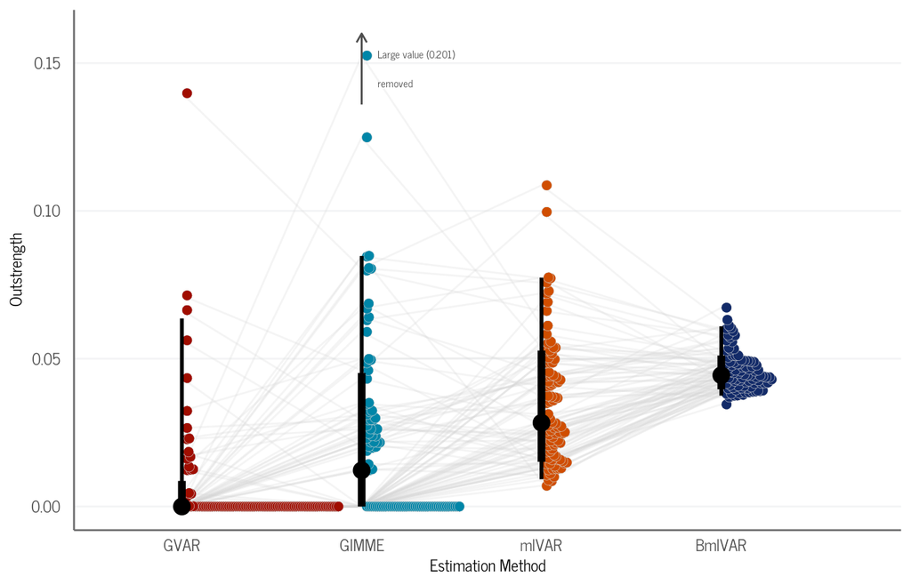

```r
df_outstrength <- data.frame(
  method = rep(c("GVAR", "GIMME","mlVAR",  "BmlVAR"), each = n_id),
  est_outstrength = c(
    df_regression_scaled$gvar$est_outstrength,
    df_regression_scaled$gimme$est_outstrength,
    df_regression_scaled$mlvar$est_outstrength,
    df_regression_scaled$bmlvar$est_outstrength
  ),
  id = rep(seq(1:n_id), 4)
)

y_limit <- 0.16
outliers <- df_outstrength |>
  dplyr::filter(est_outstrength > y_limit) |>
  dplyr::mutate(method = factor(method,
                         levels = c("GVAR",  "GIMME", "mlVAR", "BmlVAR"))) |>
  dplyr::group_by(method) |>
  dplyr::summarize(outlier_values = paste0(round(est_outstrength, 3), collapse = ", "),
            max_outlier = max(est_outstrength)) |>
  dplyr::mutate(outlier_values = if_else(method == "GVAR",
                                  paste0("Large value (", outlier_values, ")\nremoved"),
                                  paste0("Large value (", outlier_values, ")\nremoved")))

outstrength_dist <- df_outstrength |>
  dplyr::mutate(method = factor(method,
                         levels = c("GVAR",  "GIMME", "mlVAR", "BmlVAR"))) |>
  dplyr::mutate(id = as.factor(id)) |>
  ggplot(aes(x = method, y = est_outstrength, fill = method, col = method)) +
  geom_line(aes(group = id), alpha = 0.25)+
  ggdist::geom_dots(scale = 0.9, stackratio = 0.2,  layout = "swarm", linewidth = .15)+
  ggdist::stat_pointinterval(color = "black", interval_size_range = c(1,2))+
  theme_centrality() +
  labs(
    # title = "Raincloud Plot of Estimation Densities",
    x = "Estimation Method",
    y = "Outstrength",
    fill = "Method"
  ) +
  theme(legend.position = "none") +
  scale_y_continuous(limits = c(0, y_limit))+
  scale_fill_manual(values = cond_colors)+
  scale_color_manual(values = rep("#D3D3D3",4))+
  # label outliers
  geom_segment(data = outliers,
               aes(x = as.numeric(method), xend = as.numeric(method),
                   y =  y_limit * 0.85, yend =  y_limit),
               arrow = arrow(length = unit(0.2, "cm")),
               color = "grey30")+
  geom_text(data = outliers,
            aes(x = as.numeric(method) + .09,
                y = y_limit * 0.925, label = outlier_values),
            color = "grey30", size = 4, inherit.aes = FALSE, hjust = 0)

outstrength_dist
```

```r
ggsave(here::here("figures/empirical_example/outstrength_distribution.pdf"), width = 9 * 0.8, height = 6 * 0.8)
```

## 4.2 Network Density

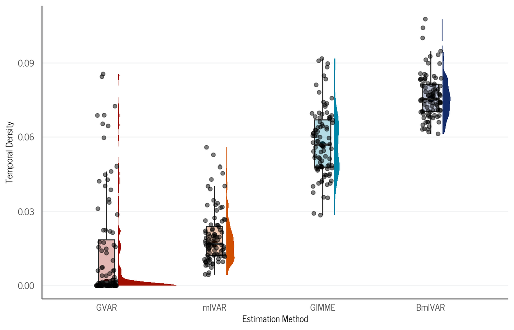

```r
df_density <- data.frame(
  method = rep(c("GVAR", "GIMME", "mlVAR", "BmlVAR"), each = n_id),
  est_dens = c(
    df_regression_scaled$gvar$est_dens,
    df_regression_scaled$mlvar$est_dens,
    df_regression_scaled$gimme$est_dens,
    df_regression_scaled$bmlvar$est_dens
  )
)

df_density |>
    mutate(method = factor(method,
                         levels = c("GVAR", "mlVAR", "GIMME", "BmlVAR"))) |>
  ggplot(aes(x = method, y = est_dens, fill = method)) +
  ggdist::stat_halfeye(adjust = 0.5, width = 0.6, .width = 0, justification = -0.2) +
  geom_boxplot(width = 0.15, outlier.shape = NA, alpha = 0.3) +
  geom_jitter(width = 0.1, alpha = 0.5) +
  theme_centrality() +
  labs(
    # title = "Raincloud Plot of Estimation Densities",
    x = "Estimation Method",
    y = "Temporal Density",
    fill = "Method"
  ) +
  theme(legend.position = "none") +
  scale_fill_manual(values = cond_colors)
```

## 4.3 Combined Table

We combine the results for different network features and network estimation methods in one table:

```r
methods <- c("GVAR", "GIMME", "mlVAR", "BmlVAR")
outcomes <- c("Density", "Outstrength")


get_standardized_estimate <- function(model_summary, type = c("estimate", "lower_ci", "upper_ci")) {
  type <- match.arg(type)
  standardized_summary <- lm.beta::lm.beta(model_summary, complete.standardization = TRUE)
  tidy_summary <- broom::tidy(standardized_summary, conf.int = TRUE)
  estimate <- tidy_summary$std_estimate[2]
  conf_ints <- confint(betaDelta::BetaDelta(model_summary))
  lower_ci <- conf_ints[1,1]
  upper_ci <- conf_ints[1,2]


  switch(type,
         estimate = estimate,
         lower_ci = lower_ci,
         upper_ci = upper_ci)
}


df_estimates_scaled <- data.frame(
  Method = rep(methods, times = 2),
  Outcome = rep(outcomes, each = 4),
  Point_Estimate = c(
    get_standardized_estimate(reg_gvar_scaled_dens, "estimate"),
    get_standardized_estimate(reg_gimme_scaled_dens, "estimate"),
    get_standardized_estimate(reg_mlvar_scaled_dens, "estimate"),
    bmlvar_scaled_reg_standardized[2,]$summary.mean,
    get_standardized_estimate(reg_gvar_scaled_outstrength, "estimate"),
    get_standardized_estimate(reg_gimme_scaled_outstrength, "estimate"),
    get_standardized_estimate(reg_mlvar_scaled_outstrength, "estimate"),
    bmlvar_scaled_reg_standardized[1,]$summary.mean
  ),
  Lower_Limit = c(
    get_standardized_estimate(reg_gvar_scaled_dens, "lower_ci"),
    get_standardized_estimate(reg_gimme_scaled_dens, "lower_ci"),
    get_standardized_estimate(reg_mlvar_scaled_dens, "lower_ci"),
    bmlvar_scaled_reg_standardized[2,]$summary.2.5.,
    get_standardized_estimate(reg_gvar_scaled_outstrength, "lower_ci"),
    get_standardized_estimate(reg_gimme_scaled_outstrength, "lower_ci"),
    get_standardized_estimate(reg_mlvar_scaled_outstrength, "lower_ci"),
    bmlvar_scaled_reg_standardized[1,]$summary.2.5.
  ),
  Upper_Limit = c(
    get_standardized_estimate(reg_gvar_scaled_dens, "upper_ci"),
    get_standardized_estimate(reg_gimme_scaled_dens, "upper_ci"),
    get_standardized_estimate(reg_mlvar_scaled_dens, "upper_ci"),
    bmlvar_scaled_reg_standardized[2,]$summary.97.5.,
    get_standardized_estimate(reg_gvar_scaled_outstrength, "upper_ci"),
    get_standardized_estimate(reg_gimme_scaled_outstrength, "upper_ci"),
    get_standardized_estimate(reg_mlvar_scaled_outstrength, "upper_ci"),
    bmlvar_scaled_reg_standardized[1,]$summary.97.5.
  )
)
df_estimates_scaled <- df_estimates_scaled |>
  pivot_wider(names_from = Outcome,
                     values_from = c(Point_Estimate, Lower_Limit, Upper_Limit),
                     names_glue = "{Outcome}_{.value}")
```

```r
# set color palette
color_palette <- MetBrewer::met.brewer("Hiroshige")[c(1:5, 8:10)]
min_val_est <- min(df_estimates_scaled$Density_Point_Estimate, df_estimates_scaled$Outstrength_Point_Estimate)
max_val_est <- max(df_estimates_scaled$Density_Point_Estimate, df_estimates_scaled$Outstrength_Point_Estimate)

# set minimum and maximum values symmetrically
min_val <- -max(abs(min_val_est), abs(max_val_est))
max_val <- max(abs(min_val_est), abs(max_val_est))

gt_table <- df_estimates_scaled |>
  gt(rowname_col = "Method") |>
  # hierarchical cols
  cols_label(
    `Density_Point_Estimate` = "Point Est.",
    `Density_Lower_Limit` = "95% Low",
    `Density_Upper_Limit` = "95% High",
    `Outstrength_Point_Estimate` = "Point Est.",
    `Outstrength_Lower_Limit` = "95% Low",
    `Outstrength_Upper_Limit` = "95% High"
  ) |>
  tab_spanner(
    label = "Density",
    columns = c(Density_Point_Estimate, Density_Lower_Limit, Density_Upper_Limit)
  ) |>
  tab_spanner(
    label = "Outstrength",
    columns = c(Outstrength_Point_Estimate, Outstrength_Lower_Limit, Outstrength_Upper_Limit)
  ) |>
  # colorblind palette
  data_color(
    columns = c(Density_Point_Estimate, Outstrength_Point_Estimate),
    domain = c(min_val, max_val),
    palette = color_palette) |>
  # round
  fmt_number(
    columns = everything(),
    decimals = 2
  ) |>
  tab_header(
    title = "Comparison of Methods Across Two Outcomes",
  ) |>
  cols_align(
    align = "center",
    columns = everything()
  )

gt_table

# save to LaTeX
gt_table |>
  gtsave(here::here("output", "empirical_example", "summary_table.tex"))
```

# 5 BmlVAR Results in more detail

## 5.1 Convergence Statistics

We additionally check the convergence of the Bayesian model by examining convergence statistics. We check all Rhats and effective sample sizes:

```r
fit_bmlvar <- readRDS(here::here("output", "empirical_example", "fit_bmlvar_empirical_scaled.rds"))

summary_bmlvar <- rstan::summary(fit_bmlvar,
                                   pars = c("Beta",
                                            "mu_Beta",
                                            "sigma_Beta",
                                            "mu_Intercepts",
                                            "sigma_Intercepts",
                                            "reg_intercept",
                                            "reg_slope_density",
                                            "sigma_residual",
                                            "Intercepts",
                                            "Sigma",
                                            "Rho_vec",
                                            "Beta_out_strength",
                                            "Beta_in_strength",
                                            "Rho_strength",
                                            "mu_regression",
                                            "reg_slope_density_z",
                                            "reg_intercept_z",
                                            "theta_sd"))$summary

# remove some posterior descriptives
summary_bmlvar <- summary_bmlvar[, !(colnames(summary_bmlvar) %in% c("25%", "75%"))]

# convergence diagnostics
rhat_bmlvar_tmp <- summary_bmlvar |> as.data.frame() |> pull(Rhat)
rhat_bmlvar_tmp <- rhat_bmlvar_tmp[!is.nan(rhat_bmlvar_tmp)]
rhat_bmlvar_mean <- mean(rhat_bmlvar_tmp, na.rm = TRUE)
rhat_bmlvar_11 <- sum(rhat_bmlvar_tmp > 1.1)/length(rhat_bmlvar_tmp)
divtrans_bmlvar <- rstan::get_num_divergent(fit_bmlvar)
```

We observed 0 divergent transitions.

## 5.2 Uncertainty of Centrality

### 5.2.1 Proportion of most central node

For each individual, we can simply count number of sampling iterations in which any node was the most central node to obtain an uncertainty statistic.

```r
# Variable names
var_names <- colnames(data_bringmann_imputed |> select(!c(subj_id, neuroticism)))


outstrength_draws <-
    rstan::extract(object = fit_bmlvar, pars = "Beta_out_strength", permute = FALSE) |>
    posterior::as_draws_matrix() |>
    as.data.frame()

# convert to long
outstrength_long <- outstrength_draws  |>
  dplyr::mutate(iteration = row_number()) |>
  pivot_longer(
    cols = starts_with("Beta_out_strength"),
    names_to = c("id", "variable"),
    names_pattern = "Beta_out_strength\\[(\\d+),(\\d+)\\]",
    values_to = "outstrength"
  ) |>
  mutate(id = as.factor(id),
         variable = as.factor(variable))
```

We now calculate the proportion of having the highest outstrength for each variable:

```r
highest_outstrength <- outstrength_long |>
  group_by(iteration, id) |>
  filter(outstrength == max(outstrength)) |>
  ungroup()

variable_counts <- highest_outstrength |>
  dplyr::group_by(id, variable) |>
  dplyr::summarise(count = n(), .groups = "drop")

total_iterations <- outstrength_long |>
  dplyr::group_by(id) |>
  dplyr::summarise(total = n_distinct(iteration), .groups = "drop")

all_combinations <- expand.grid(
  id = unique(outstrength_long$id),
  variable = unique(outstrength_long$variable)
)

complete_counts <- all_combinations |>
  left_join(variable_counts, by = c("id", "variable")) |>
  dplyr::mutate(count = replace_na(count, 0)) # Replace NA counts with 0

proportions <- complete_counts |>
  left_join(total_iterations, by = "id") |>
  dplyr::mutate(proportion = count / total) |>
  dplyr::select(id, variable, proportion)
```

### 5.2.2 Centrality uncertainty visualizations

We find two participants, one for which the most central node has a lower uncertainty, and one for which it is higher:

```r
outstrength_bmlvar <- ests_bmlvar_scaled$outstrength_est

max_outstrength <- sapply(outstrength_bmlvar$median, which.max)
outstrength_df <- data.frame(
  id = 1:92,
  most_cent = max_outstrength
)

# attach the proportions (in an ugly manner, I know)
extreme_props <- outstrength_df |>
  dplyr::mutate(id = as.factor(id),
         most_cent = as.factor(most_cent)) |>
  left_join(proportions, by = c("id" = "id", "most_cent" = "variable")) |>
  arrange(proportion) |>
  dplyr::mutate(
  lowest = min(proportion),
  highest = max(proportion)
  ) |>
  filter(proportion == lowest | proportion == highest) |>
  dplyr::mutate(most_cent = as.numeric(most_cent)) |>
  dplyr::mutate(most_cent = case_match(most_cent,
    1 ~ var_names[1],
    2 ~ var_names[2],
    3 ~ var_names[3],
    4 ~ var_names[4],
    5 ~ var_names[5],
    6 ~ var_names[6]
  ))

extreme_ids <- as.numeric(unique(extreme_props$id))

proportion_labels <- proportions |>
  filter(id %in% extreme_ids) |>
  dplyr::mutate(id = paste0("Participant ", id)) |>
  dplyr::mutate(proportion = sub("^(-?)0.", "\\1.",sprintf("%.2f", proportion))) |>
  dplyr::mutate(variable = factor(variable, levels = 1:6, labels = var_names))

# change alpha based on most cent
proportion_labels <- proportion_labels |>
  dplyr::mutate(id = as.character(id)) |>
  dplyr::mutate(variable = as.character(variable)) |>
  left_join(extreme_props |>
               select(id, most_cent) |>
              mutate(id = as.character(id),
                     most_cent = as.character(most_cent)) |>
              mutate(id = paste0("Participant ", id)),
            by = "id") |>
  # change alpha based on most cent
  dplyr::mutate(cent_alpha = if_else(variable == most_cent,
                         1, 0.9))


# for each participant, add the string "p(c_p = c_max)" to the plot above the first row
# and evaluate the text as formula
proportion_title <- proportion_labels |>
  dplyr::group_by(id) |>
  dplyr::mutate(proportion_title = "p(c[p] == c[max])") |>
  distinct(id, proportion_title) |>
  dplyr::mutate(x = 0.19, y = 6.5)
```

We then create uncertainty plots for their proportions:

```r
# add information about most central node
extreme_props <- extreme_props |>
  as.data.frame() |>
  dplyr::mutate(most_cent = as.character(most_cent)) |>
  dplyr::mutate(id = as.character(id))

outstrength_long_labeled <- outstrength_long |>
  dplyr::mutate(variable = as.character(variable)) |>
  dplyr::mutate(variable = case_match(variable,
    "1" ~ var_names[1],
    "2" ~ var_names[2],
    "3" ~ var_names[3],
    "4" ~ var_names[4],
    "5" ~ var_names[5],
    "6" ~ var_names[6]
  )) |>
  dplyr::mutate(id = as.character(id)) |>
  filter(id %in% extreme_ids) |>
  left_join(extreme_props |> select(id, most_cent), by = "id") |>
  dplyr::mutate(cent_alpha = if_else(variable == most_cent, 1, 0.60)) |>
  dplyr::mutate(interval_color = if_else(variable == most_cent, "grey70", "grey10"))


proportions <- proportions |>
  dplyr::mutate(variable = as.character(variable)) |>
  dplyr::mutate(variable = case_match(variable,
    "1" ~ var_names[1],
    "2" ~ var_names[2],
    "3" ~ var_names[3],
    "4" ~ var_names[4],
    "5" ~ var_names[5],
    "6" ~ var_names[6]
  ))

most_central_data <- outstrength_long_labeled |>
  left_join(proportions, by = c("id" = "id", "variable" = "variable")) |>
  dplyr::mutate(id = paste0("Participant ", id)) |>
  dplyr::mutate(variable = factor(variable)) |>
  filter(variable == most_cent)

other_data <- outstrength_long_labeled |>
  left_join(proportions, by = c("id" = "id", "variable" = "variable")) |>
  dplyr::mutate(id = paste0("Participant ", id)) |>
  dplyr::mutate(variable = factor(variable)) |>
  filter(variable != most_cent)

most_central_example_plot <- ggplot() +
  # non-most central variables
  ggdist::stat_halfeye(data = other_data,
                       aes(x = outstrength, y = variable, slab_alpha = cent_alpha),
                       .width = c(.66, .95),
                       fill = cond_colors[4],
                       color = "grey10",
                       point_fill = "grey10",
                       point_color = "grey10",
                       point_alpha = 1,
                       interval_alpha = 1,
                       scale = 0.95,
                       show.legend = FALSE) +
  # most central variables
  ggdist::stat_halfeye(data = most_central_data,
                       aes(x = outstrength, y = variable, slab_alpha = cent_alpha),
                       .width = c(.66, .95),
                       fill = cond_colors[4],
                       color = "grey70",
                       point_fill = "grey70",
                       point_color = "grey70",
                       point_alpha = 1,
                       interval_alpha = 1,
                       scale = 0.95,
                       show.legend = FALSE) +
  geom_text(data = proportion_labels,
            aes(x = 0.19, y = variable, label = proportion),
            hjust = 0, vjust = -0.8, size = 4, color = "#6d6d6e") +
  geom_text(data = proportion_title,
            aes(x = x, y = y, label = proportion_title),
            hjust = 0.4, vjust = 0, size = 4, parse = TRUE, color = "#6d6d6e") +
  facet_wrap(~id, axes = "all") +
  theme_centrality() +
  theme(axis.text.y = element_text(size = 14),
        axis.text.x = element_text(size = 14),
        strip.text.x.top = element_text(size = 17),
        plot.title = element_text(size = 22),
        panel.grid.major.y = element_blank(),
        panel.grid.minor.y = element_blank()) +
  labs(y = "", x = "Outstrength") +
  guides(alpha = "none")
most_central_example_plot

ggsave(here::here("figures", "empirical_example", "most_central_example_plot.pdf"), width = 9 * 0.9, height = 6 * 0.9)
```

## 5.3 Prior Predictive

To better understand our model, we can simulate from our priors. We can use that, for example, to understand the implied prior on the outstrength centrality. We do not place a prior directly on the centrality, but rather on the individual coefficients going into its sum.

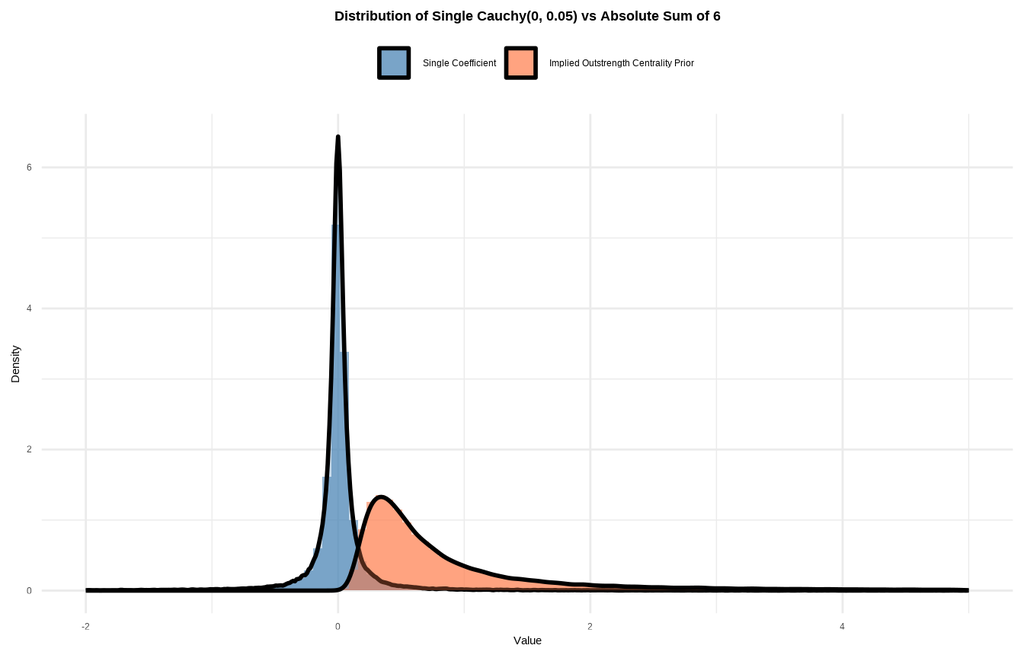

```r
n_sim <- 100000

# Simulate from Cauchy(0, 0.05)
# rcauchy uses location and scale parameters
cauchy_samples <- matrix(rcauchy(n_sim * 6, location = 0, scale = 0.05),
                         nrow = n_sim, ncol = 6)

# obtain single coefficient and sum of coefficients
single_coef <- cauchy_samples[, 1]
abs_sum <- rowSums(abs(cauchy_samples))

# create data frame for plotting
df <- data.frame(
  single = single_coef,
  abs_sum = abs_sum
)

# reshape to long format for ggplot
df_long <- pivot_longer(df, cols = everything(),
                        names_to = "type",
                        values_to = "value")

# rename for better labels
df_long$type <- factor(df_long$type,
                       levels = c("single", "abs_sum"),
                       labels = c("Single Coefficient",
                                  "Implied Outstrength Centrality Prior"))

# create the plot
ggplot(df_long, aes(x = value, fill = type)) +
  geom_histogram(aes(y = after_stat(density)),
                 bins = 100, alpha = 0.6, position = "identity") +
  geom_density(alpha = 0.3, linewidth = 1) +
  scale_fill_manual(values = c("steelblue", "coral")) +
  xlim(-2, 5) +
  labs(title = "Distribution of Single Cauchy(0, 0.05) vs Absolute Sum of 6",
       x = "Value",
       y = "Density",
       fill = "") +
  theme_minimal() +
  theme(legend.position = "top",
        plot.title = element_text(hjust = 0.5, face = "bold"))
```

## 5.4 Posterior Predictive

An additional advantage of Bayesian inference is the use of posterior predictive simulations, where we can compare predictive simulations from the posterior with the true observed data patterns. Here, this indicates that we did not accurately capture the observed data pattern.

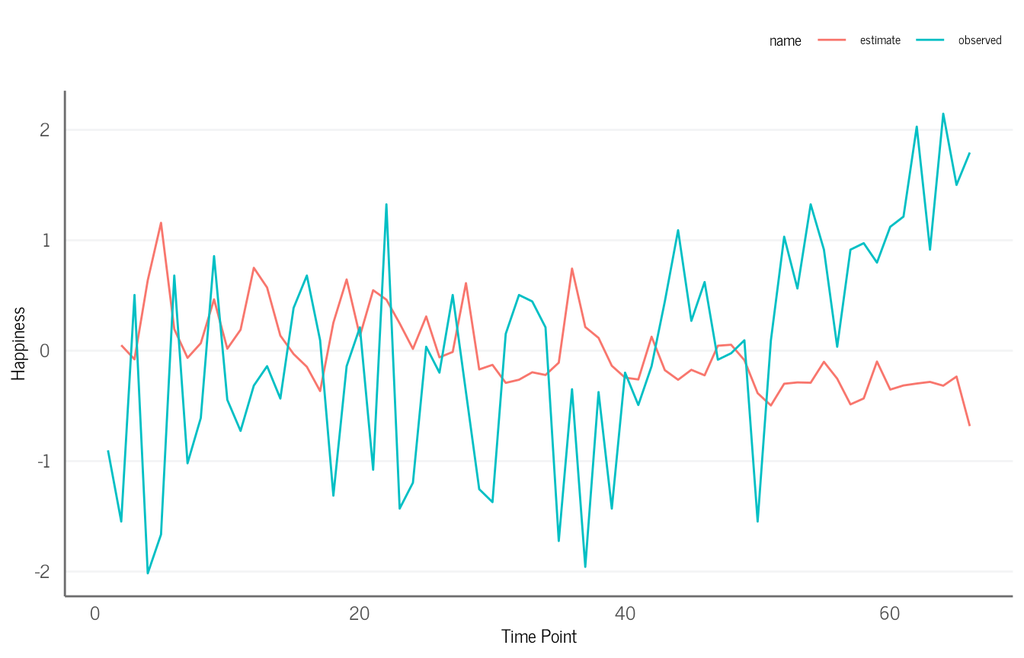

```r
y_rep_draws <- rstan::extract(fit_bmlvar, "Y_rep")

posterior_draws <- y_rep_draws$Y_rep

# transpose posterior_draws
posterior_draws <- aperm(y_rep_draws$Y_rep, c(2,1,3))

# Sample 200 columns
posterior_samples <- posterior_draws[, sample(dim(posterior_draws)[2], 200),]

# split into list
samples_list <- plyr::alply(posterior_samples, 3)

# convert to dataframe with id
samples_list <- lapply(samples_list, function(x){
  x |>
    as.data.frame() |>
    mutate(subj_id = data_bringmann_imputed$subj_id) |>
    dplyr::group_by(subj_id) |>
    dplyr::mutate(obs = row_number()) |>
    dplyr::ungroup() |>
    pivot_longer(cols = !c(subj_id, obs),
                 values_to = "est",
                 names_to = "iter") |>
    dplyr::mutate(iter = as.numeric(gsub("V", "", iter)))
})


# plot example participant with second variable (happy)
samples_list[[2]] |>
  dplyr::filter(subj_id == "31") |>
  dplyr::group_by(obs) |>
  dplyr::summarize(est_mean = mean(est)) |>
  ungroup() |>
  # attach observed centered data
  bind_cols(df_data_scaled |> filter(subj_id == 31) |> select(happy)) |>
  dplyr::rename(estimate = est_mean,
         observed = happy) |>
  pivot_longer(!obs) |>
  ggplot(aes(x = obs, y = value, color = name)) +
  geom_line()+
  theme_centrality()+
  labs(x = "Time Point",
       y = "Happiness")+
  theme(text = element_text(size = 15))
```

# 6 Print to normal R script

```r
knitr::purl(here::here("scripts", "02_empirical_example_bringmann_2016.qmd"),
            output = here::here("scripts", "02_empirical_example_bringmann_2016.R"),
            documentation = 2)
```